# Risk Factor Analysis

## Outcome Variable

**Outcome Variable:** dead

## Predictor Variables

**Intervention Variable:** ever_sunderweight024

**Adjustment Set:**

unadjusted

## Stratifying Variables

The analysis was stratified on these variable(s):

- studyid
- country

## Data Summary

| studyid | country | ever_sunderweight024 | dead | n_cell | n |
| --- | --- | --- | --- | --- | --- |
| ki0047075b-MAL-ED | BANGLADESH | 0 | 0 | 223 | 263 |
| ki0047075b-MAL-ED | BANGLADESH | 0 | 1 | 1 | 263 |
| ki0047075b-MAL-ED | BANGLADESH | 1 | 0 | 38 | 263 |
| ki0047075b-MAL-ED | BANGLADESH | 1 | 1 | 1 | 263 |
| ki0047075b-MAL-ED | INDIA | 0 | 0 | 200 | 251 |
| ki0047075b-MAL-ED | INDIA | 0 | 1 | 1 | 251 |
| ki0047075b-MAL-ED | INDIA | 1 | 0 | 49 | 251 |
| ki0047075b-MAL-ED | INDIA | 1 | 1 | 1 | 251 |
| ki0047075b-MAL-ED | PERU | 0 | 0 | 288 | 302 |
| ki0047075b-MAL-ED | PERU | 0 | 1 | 2 | 302 |
| ki0047075b-MAL-ED | PERU | 1 | 0 | 12 | 302 |
| ki0047075b-MAL-ED | PERU | 1 | 1 | 0 | 302 |
| ki0047075b-MAL-ED | SOUTH AFRICA | 0 | 0 | 290 | 312 |
| ki0047075b-MAL-ED | SOUTH AFRICA | 0 | 1 | 0 | 312 |
| ki0047075b-MAL-ED | SOUTH AFRICA | 1 | 0 | 22 | 312 |
| ki0047075b-MAL-ED | SOUTH AFRICA | 1 | 1 | 0 | 312 |
| ki0047075b-MAL-ED | TANZANIA, UNITED REPUBLIC OF | 0 | 0 | 224 | 261 |
| ki0047075b-MAL-ED | TANZANIA, UNITED REPUBLIC OF | 0 | 1 | 2 | 261 |
| ki0047075b-MAL-ED | TANZANIA, UNITED REPUBLIC OF | 1 | 0 | 34 | 261 |
| ki0047075b-MAL-ED | TANZANIA, UNITED REPUBLIC OF | 1 | 1 | 1 | 261 |
| ki1000304b-SAS-CompFeed | INDIA | 0 | 0 | 1119 | 1512 |
| ki1000304b-SAS-CompFeed | INDIA | 0 | 1 | 20 | 1512 |
| ki1000304b-SAS-CompFeed | INDIA | 1 | 0 | 356 | 1512 |
| ki1000304b-SAS-CompFeed | INDIA | 1 | 1 | 17 | 1512 |
| ki1000304b-SAS-FoodSuppl | INDIA | 0 | 0 | 231 | 414 |
| ki1000304b-SAS-FoodSuppl | INDIA | 0 | 1 | 2 | 414 |
| ki1000304b-SAS-FoodSuppl | INDIA | 1 | 0 | 179 | 414 |
| ki1000304b-SAS-FoodSuppl | INDIA | 1 | 1 | 2 | 414 |
| ki1017093b-PROVIDE | BANGLADESH | 0 | 0 | 620 | 699 |
| ki1017093b-PROVIDE | BANGLADESH | 0 | 1 | 4 | 699 |
| ki1017093b-PROVIDE | BANGLADESH | 1 | 0 | 75 | 699 |
| ki1017093b-PROVIDE | BANGLADESH | 1 | 1 | 0 | 699 |
| ki1066203-TanzaniaChild2 | TANZANIA, UNITED REPUBLIC OF | 0 | 0 | 2263 | 2395 |
| ki1066203-TanzaniaChild2 | TANZANIA, UNITED REPUBLIC OF | 0 | 1 | 1 | 2395 |
| ki1066203-TanzaniaChild2 | TANZANIA, UNITED REPUBLIC OF | 1 | 0 | 131 | 2395 |
| ki1066203-TanzaniaChild2 | TANZANIA, UNITED REPUBLIC OF | 1 | 1 | 0 | 2395 |
| ki1101329-Keneba | GAMBIA | 0 | 0 | 2380 | 2880 |
| ki1101329-Keneba | GAMBIA | 0 | 1 | 42 | 2880 |
| ki1101329-Keneba | GAMBIA | 1 | 0 | 439 | 2880 |
| ki1101329-Keneba | GAMBIA | 1 | 1 | 19 | 2880 |
| ki1113344-GMS-Nepal | NEPAL | 0 | 0 | 392 | 602 |
| ki1113344-GMS-Nepal | NEPAL | 0 | 1 | 2 | 602 |
| ki1113344-GMS-Nepal | NEPAL | 1 | 0 | 205 | 602 |
| ki1113344-GMS-Nepal | NEPAL | 1 | 1 | 3 | 602 |
| ki1126311-ZVITAMBO | ZIMBABWE | 0 | 0 | 12152 | 13908 |
| ki1126311-ZVITAMBO | ZIMBABWE | 0 | 1 | 800 | 13908 |
| ki1126311-ZVITAMBO | ZIMBABWE | 1 | 0 | 723 | 13908 |
| ki1126311-ZVITAMBO | ZIMBABWE | 1 | 1 | 233 | 13908 |
| kiGH5241-JiVitA-3 | BANGLADESH | 0 | 0 | 22371 | 26821 |
| kiGH5241-JiVitA-3 | BANGLADESH | 0 | 1 | 370 | 26821 |
| kiGH5241-JiVitA-3 | BANGLADESH | 1 | 0 | 3917 | 26821 |
| kiGH5241-JiVitA-3 | BANGLADESH | 1 | 1 | 163 | 26821 |
| kiGH5241-JiVitA-4 | BANGLADESH | 0 | 0 | 4604 | 5429 |
| kiGH5241-JiVitA-4 | BANGLADESH | 0 | 1 | 27 | 5429 |
| kiGH5241-JiVitA-4 | BANGLADESH | 1 | 0 | 785 | 5429 |
| kiGH5241-JiVitA-4 | BANGLADESH | 1 | 1 | 13 | 5429 |

The following strata were considered:

- studyid: ki0047075b-MAL-ED, country: BANGLADESH
- studyid: ki0047075b-MAL-ED, country: INDIA
- studyid: ki0047075b-MAL-ED, country: PERU
- studyid: ki0047075b-MAL-ED, country: SOUTH AFRICA
- studyid: ki0047075b-MAL-ED, country: TANZANIA, UNITED REPUBLIC OF
- studyid: ki1000304b-SAS-CompFeed, country: INDIA
- studyid: ki1000304b-SAS-FoodSuppl, country: INDIA
- studyid: ki1017093b-PROVIDE, country: BANGLADESH
- studyid: ki1066203-TanzaniaChild2, country: TANZANIA, UNITED REPUBLIC OF
- studyid: ki1101329-Keneba, country: GAMBIA
- studyid: ki1113344-GMS-Nepal, country: NEPAL
- studyid: ki1126311-ZVITAMBO, country: ZIMBABWE
- studyid: kiGH5241-JiVitA-3, country: BANGLADESH
- studyid: kiGH5241-JiVitA-4, country: BANGLADESH

### Dropped Strata

Some strata were dropped due to rare outcomes:

- studyid: ki0047075b-MAL-ED, country: BANGLADESH
- studyid: ki0047075b-MAL-ED, country: INDIA
- studyid: ki0047075b-MAL-ED, country: PERU
- studyid: ki0047075b-MAL-ED, country: SOUTH AFRICA
- studyid: ki0047075b-MAL-ED, country: TANZANIA, UNITED REPUBLIC OF
- studyid: ki1000304b-SAS-FoodSuppl, country: INDIA
- studyid: ki1017093b-PROVIDE, country: BANGLADESH
- studyid: ki1066203-TanzaniaChild2, country: TANZANIA, UNITED REPUBLIC OF
- studyid: ki1113344-GMS-Nepal, country: NEPAL

## Methods Detail

We’re interested in the causal parameters $E[Y_a]$ for all values of $a \in \mathcal{A}$. These parameters represent the mean outcome if, possibly contrary to fact, we intervened to set all units to have $A=a$. Under the randomization and positivity assumptions, these are identified by the statistical parameters $\psi_a=E_W[E_{Y|A,W}(Y|A=a,W)]$. In addition, we’re interested in the mean of $Y$, $E[Y]$ under no intervention (the observed mean). We will estimate these parameters by using SuperLearner to fit the relevant likelihood factors – $E_{Y|A,W}(Y|A=a,W)$ and $p(A=a|W)$, and then updating our likelihood fit using a joint TMLE.

For unadjusted analyses ($W=\{\}$), initial likelihoods were estimated using Lrnr_glm to estimate the simple $E(Y|A)$ and Lrnr_mean to estimate $p(A)$. For adjusted analyses, a small library containing Lrnr_glmnet, Lrnr_xgboost, and Lrnr_mean was used.

Having estimated these parameters, we will then use the delta method to estimate relative risks and attributable risks relative to a prespecified baseline level of $A$.

# Results Detail

## Results Plots

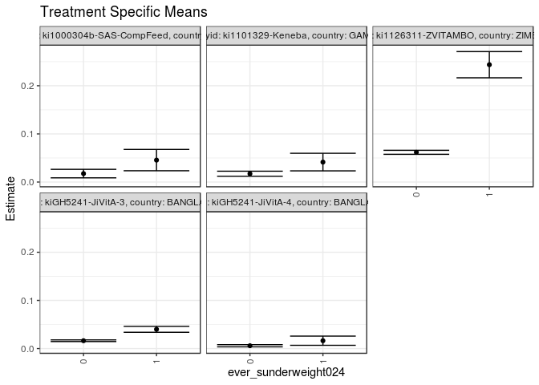

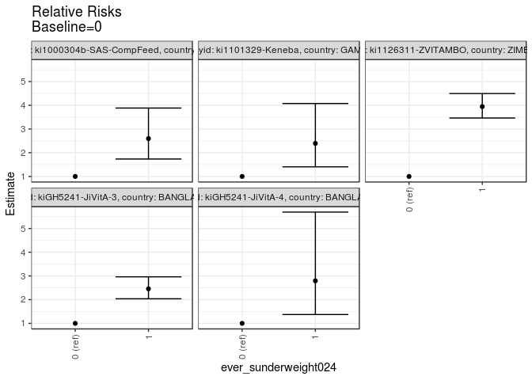

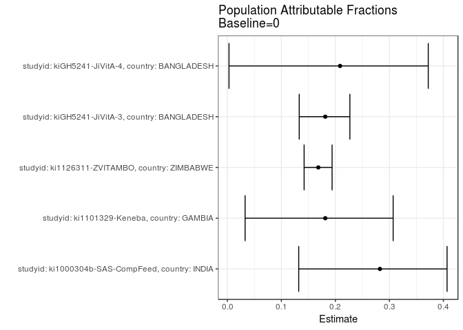

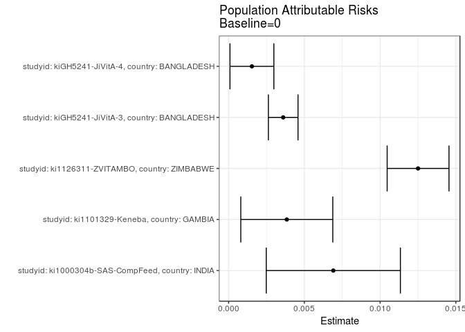

## Results Table

### Parameter: TSM

| studyid | country | intervention_level | baseline_level | estimate | ci_lower | ci_upper |
| --- | --- | --- | --- | --- | --- | --- |
| ki1000304b-SAS-CompFeed | INDIA | 0 | NA | 0.0175593 | 0.0087313 | 0.0263872 |
| ki1000304b-SAS-CompFeed | INDIA | 1 | NA | 0.0455764 | 0.0234188 | 0.0677340 |
| ki1101329-Keneba | GAMBIA | 0 | NA | 0.0173410 | 0.0121414 | 0.0225407 |
| ki1101329-Keneba | GAMBIA | 1 | NA | 0.0414847 | 0.0232191 | 0.0597503 |
| ki1126311-ZVITAMBO | ZIMBABWE | 0 | NA | 0.0617665 | 0.0576205 | 0.0659125 |
| ki1126311-ZVITAMBO | ZIMBABWE | 1 | NA | 0.2437238 | 0.2165079 | 0.2709398 |
| kiGH5241-JiVitA-3 | BANGLADESH | 0 | NA | 0.0162702 | 0.0145902 | 0.0179502 |
| kiGH5241-JiVitA-3 | BANGLADESH | 1 | NA | 0.0399510 | 0.0338018 | 0.0461002 |
| kiGH5241-JiVitA-4 | BANGLADESH | 0 | NA | 0.0058303 | 0.0035331 | 0.0081274 |
| kiGH5241-JiVitA-4 | BANGLADESH | 1 | NA | 0.0162907 | 0.0067447 | 0.0258368 |

### Parameter: E(Y)

| studyid | country | intervention_level | baseline_level | estimate | ci_lower | ci_upper |
| --- | --- | --- | --- | --- | --- | --- |
| ki1000304b-SAS-CompFeed | INDIA | NA | NA | 0.0244709 | 0.0133812 | 0.0355606 |
| ki1101329-Keneba | GAMBIA | NA | NA | 0.0211806 | 0.0159210 | 0.0264401 |
| ki1126311-ZVITAMBO | ZIMBABWE | NA | NA | 0.0742738 | 0.0699158 | 0.0786318 |
| kiGH5241-JiVitA-3 | BANGLADESH | NA | NA | 0.0198725 | 0.0181763 | 0.0215687 |
| kiGH5241-JiVitA-4 | BANGLADESH | NA | NA | 0.0073678 | 0.0049728 | 0.0097628 |

### Parameter: RR

| studyid | country | intervention_level | baseline_level | estimate | ci_lower | ci_upper |
| --- | --- | --- | --- | --- | --- | --- |
| ki1000304b-SAS-CompFeed | INDIA | 0 | 0 | 1.000000 | 1.000000 | 1.000000 |
| ki1000304b-SAS-CompFeed | INDIA | 1 | 0 | 2.595576 | 1.734279 | 3.884621 |
| ki1101329-Keneba | GAMBIA | 0 | 0 | 1.000000 | 1.000000 | 1.000000 |
| ki1101329-Keneba | GAMBIA | 1 | 0 | 2.392285 | 1.404313 | 4.075323 |
| ki1126311-ZVITAMBO | ZIMBABWE | 0 | 0 | 1.000000 | 1.000000 | 1.000000 |
| ki1126311-ZVITAMBO | ZIMBABWE | 1 | 0 | 3.945889 | 3.463867 | 4.494988 |
| kiGH5241-JiVitA-3 | BANGLADESH | 0 | 0 | 1.000000 | 1.000000 | 1.000000 |
| kiGH5241-JiVitA-3 | BANGLADESH | 1 | 0 | 2.455474 | 2.035893 | 2.961527 |
| kiGH5241-JiVitA-4 | BANGLADESH | 0 | 0 | 1.000000 | 1.000000 | 1.000000 |
| kiGH5241-JiVitA-4 | BANGLADESH | 1 | 0 | 2.794161 | 1.371794 | 5.691336 |

### Parameter: PAR

| studyid | country | intervention_level | baseline_level | estimate | ci_lower | ci_upper |
| --- | --- | --- | --- | --- | --- | --- |
| ki1000304b-SAS-CompFeed | INDIA | 0 | NA | 0.0069116 | 0.0024833 | 0.0113400 |
| ki1101329-Keneba | GAMBIA | 0 | NA | 0.0038395 | 0.0008022 | 0.0068768 |
| ki1126311-ZVITAMBO | ZIMBABWE | 0 | NA | 0.0125073 | 0.0104661 | 0.0145484 |
| kiGH5241-JiVitA-3 | BANGLADESH | 0 | NA | 0.0036023 | 0.0026246 | 0.0045800 |
| kiGH5241-JiVitA-4 | BANGLADESH | 0 | NA | 0.0015376 | 0.0000888 | 0.0029863 |

### Parameter: PAF

| studyid | country | intervention_level | baseline_level | estimate | ci_lower | ci_upper |
| --- | --- | --- | --- | --- | --- | --- |
| ki1000304b-SAS-CompFeed | INDIA | 0 | NA | 0.2824431 | 0.1320854 | 0.4067528 |
| ki1101329-Keneba | GAMBIA | 0 | NA | 0.1812755 | 0.0328359 | 0.3069326 |
| ki1126311-ZVITAMBO | ZIMBABWE | 0 | NA | 0.1683942 | 0.1420900 | 0.1938919 |
| kiGH5241-JiVitA-3 | BANGLADESH | 0 | NA | 0.1812715 | 0.1330443 | 0.2268158 |
| kiGH5241-JiVitA-4 | BANGLADESH | 0 | NA | 0.2086860 | 0.0029919 | 0.3719431 |